# Spring 2023 GE 461 Introduction to Data Science - Project 1

The last condition is **constant variability**, which says that variability of points around the least squares line should be roughly constant. This implies that the variability of residuals around the zero line should be roughly constant as well.

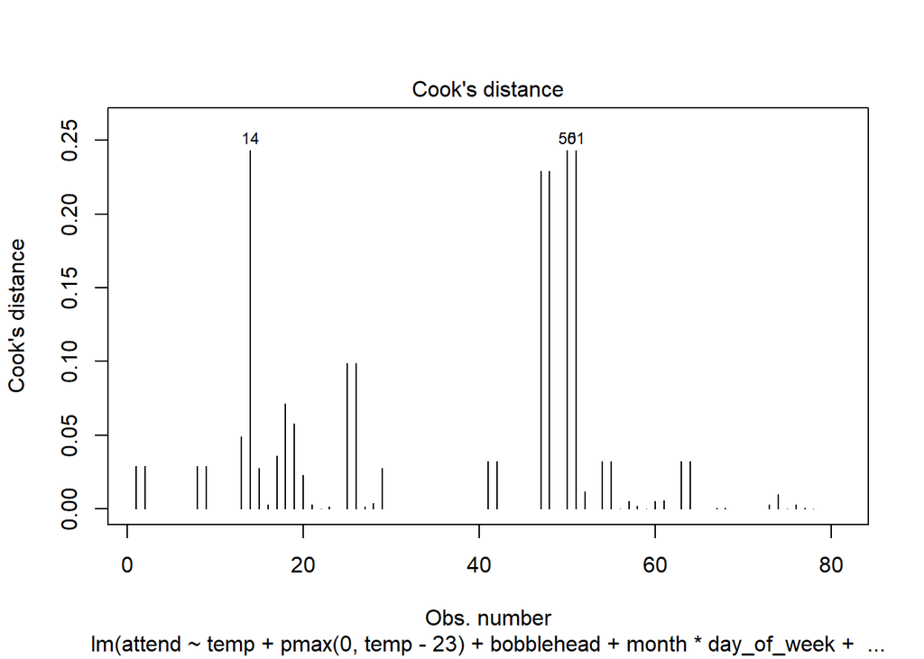

```r
plot(model4, which=4)
```

```r
ncvTest(model4)
```

```
## Non-constant Variance Score Test
## Variance formula: ~ fitted.values
## Chisquare = 3.077977, Df = 1, p = 0.079359
```

Null hypothesis says the variance is constant. Since p is big (>.05), the test says that the variance is constant along the residuals.

Also, check if there is any **influential point**.

```r
# Generate Cook's distance values
cooksd <- cooks.distance(model4)

# Identify influential observations
which(cooksd > 1)
```

```
## named integer(0)
```

So, there is **no influential point**.

Diagnostic plots show that **the model meets the requirements of linear regression**.

Also, adjusted R2 values and AIC support that the best model is model4.

```r
summary(model4)
```

```
##
## Call:
## lm(formula = attend ~ temp + pmax(0, temp - 23) + bobblehead +
##     month * day_of_week + temp * shirt + fireworks * opponent +
##     cap, data = events)
##
## Residuals:
##     Min      1Q  Median      3Q     Max
## -5746.5  -329.1     0.0   229.3  5806.5
##
## Coefficients: (20 not defined because of singularities)
##                                Estimate Std. Error t value Pr(>|t|)
## (Intercept)                      1704.3    29615.9   0.058  0.95498
## temp                              820.3     1135.0   0.723  0.48268
## pmax(0, temp - 23)               -805.5     1320.7  -0.610  0.55245
## bobbleheadYES                   17700.5     5816.5   3.043  0.00942 **
## monthMAY                        16760.0    21332.6   0.786  0.44616
## monthJUN                         9587.2    15010.5   0.639  0.53411
## monthJUL                        12701.0    22903.9   0.555  0.58863
## monthAUG                        11544.0    21378.6   0.540  0.59834
## monthSEP                         2724.7    14982.1   0.182  0.85849
## monthOCT                         8474.9    23720.7   0.357  0.72662
## day_of_weekTuesday              17737.9     7008.4   2.531  0.02508 *
## day_of_weekWednesday            -2591.6     6433.4  -0.403  0.69361
## day_of_weekThursday             -4912.7     8466.9  -0.580  0.57168
## day_of_weekFriday              -10787.2    15897.6  -0.679  0.50933
## day_of_weekSaturday             23204.9    12308.7   1.885  0.08194 .
## day_of_weekSunday               11733.8     9761.3   1.202  0.25078
## shirtYES                        22862.3    12383.6   1.846  0.08776 .
## fireworksYES                    20684.5    10398.3   1.989  0.06814 .
## opponentAstros                  -4456.5    27411.0  -0.163  0.87335
## opponentBraves                  11547.5    21472.3   0.538  0.59981
## opponentBrewers                   127.8    26868.7   0.005  0.99628
## opponentCardinals                 728.2    26862.1   0.027  0.97879
## opponentCubs                     5790.4    31989.4   0.181  0.85915
## opponentGiants                   4475.2    27174.4   0.165  0.87172
## opponentMarlins                  -957.9    31540.4  -0.030  0.97623
## opponentMets                     8114.5    17316.2   0.469  0.64711
## opponentNationals               -6413.4    19568.9  -0.328  0.74833
## opponentPadres                  10156.2    20827.2   0.488  0.63392
```

[output cut: 51 more lines]

```
## fireworksYES:opponentMets       10368.4     9891.3   1.048  0.31363
## fireworksYES:opponentNationals  24033.8    11561.7   2.079  0.05801 .
## fireworksYES:opponentPadres          NA         NA      NA       NA
## fireworksYES:opponentPhillies        NA         NA      NA       NA
## fireworksYES:opponentPirates         NA         NA      NA       NA
## fireworksYES:opponentReds            NA         NA      NA       NA
## fireworksYES:opponentRockies         NA         NA      NA       NA
## fireworksYES:opponentSnakes          NA         NA      NA       NA
## fireworksYES:opponentWhite Sox       NA         NA      NA       NA
## ---
## Signif. codes:  0 '***' 0.001 '**' 0.01 '*' 0.05 '.' 0.1 ' ' 1
##
## Residual standard error: 4844 on 13 degrees of freedom
## Multiple R-squared:  0.9446, Adjusted R-squared:  0.6592
## F-statistic: 3.309 on 67 and 13 DF,  p-value: 0.0102
```

## Question - 1

Now we will answer the question “does bobblehead still increase the attendance?”.

We can answer this by checking the coefficient of bobblehead in the final model.

Expected number of additional fans drawn to a home game with a bobblehead promotion;

```r
model4 %>% coef %>% .["bobbleheadYES"]
```

```
## bobbleheadYES
##       17700.5
```

So, the point estimate is 17701.

The confidence interval is (95%);

```r
confint(model4, parm= "bobbleheadYES")
```

```
##                  2.5 %   97.5 %
## bobbleheadYES 5134.746 30266.26
```

## Question - 2

Using our model, we can predict the number of attendees to a typical home game, - on a Wednesday,

- in June,
- the bobblehead promotion is applied,
- opponent is Angels,
- day_night is day,
- skies is clear,
- day is 4,
- temperature is 24,
- other promotions are not applied.

Besides point estimate, give a 90% prediction interval.

```r
prediction_data <- data.table(day_of_week = "Wednesday",
                       month = "JUN",
                       bobblehead = "YES",
                       opponent = "Angels",
                       day_night = "Day",
                       skies = "Clear",
                       day = "4",
                       temp = 24,
                       shirt = "NO",
                       fireworks = "NO",
                       cap = "NO")

predict(object=model4, prediction_data)
```

```
##        1
## 64490.34
```

So, the point estimate is 64490. The 90% prediction interval is,

```r
predict(object=model4, prediction_data, interval = "prediction", level = 0.9)
```

```
##        fit      lwr      upr
## 1 64490.34 45032.33 83948.34
```